# Snail Kite Population Viability Analysis with State-Space models

Does adding detectability to the observation error model helps?

José Miguel Ponciano, Orlando Acevedo-Charry, Caroline Poli, Meghan Beatty, Lara Elmquist, & Miguel A. Acevedo

16 July 2025

## 0.1 Objective

The purpose of this document is to explore the statistical properties of a model where we include an under-reporting probability in the sampling error model.

```r
# R functions and datasets to support "Modern Applied Statistics with S",
  #a book from W.N. Venables and B.D. Ripley
library(MASS);
# R functions for Data Cloning (maximum likelihood estimation using Bayesian MCMC)
library(dclone);
# Create plots for MCMC output
library(mcmcplots)
# Data manipulation and elegant figures
library(tidyverse)
# Palettes inspired by works at the Metropolitan Museum of Art in New York
library(MetBrewer)
```

First we read the data

```r
rawdat <- read.csv("Code/snailkite counts 1997_2025.csv")
head(rawdat, 12) # first 12 rows
```

|  | X | year | survey_num | EAST | EVER | KRV | OKEE | PP | SJM | OTHER |
| --- | --- | --- | --- | --- | --- | --- | --- | --- | --- | --- |
| 1 | 1 | 1997 | 1 | 3 | 123 | 36 | 28 | NA | 47 | NA |
| 2 | 2 | 1997 | 2 | 2 | 67 | 19 | 20 | NA | 33 | NA |
| 3 | 3 | 1997 | 3 | 5 | 118 | 30 | 22 | NA | 26 | NA |
| 4 | 4 | 1997 | 4 | 3 | 106 | 27 | 32 | NA | 34 | NA |
| 5 | 5 | 1997 | 5 | 14 | 240 | 36 | 88 | NA | 29 | NA |
| 6 | 6 | 1997 | 6 | 7 | 131 | 28 | 33 | NA | 32 | NA |
| 7 | 7 | 1998 | 1 | 12 | 127 | 3 | 19 | NA | 16 | NA |
| 8 | 8 | 1998 | 2 | 0 | 226 | 17 | NA | NA | 22 | NA |
| 9 | 9 | 1998 | 3 | 5 | 168 | 20 | 59 | NA | 17 | NA |
| 10 | 10 | 1998 | 4 | 5 | 229 | 11 | 28 | NA | 46 | NA |

[output cut: 2 more lines]

```r
tail(rawdat, 12) # last 12 rows
```

|  | X | year | survey_num | EAST | EVER | KRV | OKEE | PP | SJM | OTHER |
| --- | --- | --- | --- | --- | --- | --- | --- | --- | --- | --- |
| 163 | 163 | 2024 | 1 | 2 | 0 | 214 | 222 | 2 | 64 | 12 |
| 164 | 164 | 2024 | 2 | 7 | 0 | 224 | 294 | NA | 55 | 15 |
| 165 | 165 | 2024 | 3 | 8 | 0 | 156 | 295 | 0 | 50 | 25 |
| 166 | 166 | 2024 | 4 | NA | 0 | 161 | 291 | NA | 40 | NA |
| 167 | 167 | 2024 | 5 | NA | 0 | 173 | 180 | NA | 56 | 18 |
| 168 | 168 | 2024 | 6 | 36 | 0 | 114 | 107 | NA | 27 | 31 |
| 169 | 169 | 2025 | 1 | 22 | 0 | 37 | 62 | NA | 56 | 7 |
| 170 | 170 | 2025 | 2 | 32 | 0 | 23 | 28 | NA | NA | 36 |
| 171 | 171 | 2025 | 3 | NA | NA | NA | NA | NA | NA | 2 |
| 172 | 172 | 2025 | 4 | NA | NA | NA | NA | NA | NA | NA |

[output cut: 2 more lines]

We can extract information from this dataset to be organized according to the modeling requirements:

```r
names.rawdat <- names(rawdat)
deme.names <- c("EAST","EVER","KRV","OKEE","PP","SJM","OTHER" )
cols.with.counts <- match(deme.names, names.rawdat)

years <- unique(rawdat$year)
nyears <- length(years)
year.col <- which(names.rawdat=="year",arr.in=TRUE)
```

We are using a simple time scale from 0 to 28 `tt`, but we can use the ‘years’ vector above to do the plots.

```r
tt <- years - years[1]
```

We can also organize the number of surveys

```r
# List the survey numbers:
surv.num <- unique(rawdat$survey_num)
```

We can save the reorganized data in a list of three matrices, one per survey (Surveys 4, 5, and 6 are `S4mat`, `S5mat`, and `S6mat`, respectively). We can also extract the NA presence in a list of three matrices (`NAS.list <- list(NA4mat = S4mat, NA5mat=S5mat, NA6mat=S6mat)`).

```r
S4mat <- S5mat <- S6mat <- matrix(0, nrow=7, ncol=nyears)

Counts.list <- list(S4mat = S4mat, S5mat=S5mat, S6mat=S6mat)
NAS.list  <- list(NA4mat = S4mat, NA5mat=S5mat, NA6mat=S6mat)
short.inds.list <- list()
```

And finally, we can iterativelly for each of the three surveys (`i in 1:3`) fill the matrices in the empty lists. First we will use the survey number to locate our survey of interest (`surv.num[(i+3)]`). Then, we ask the row number of the surveys within the `rawdat` dataset. We extract the rows for each survey in each region or subpopulation, and transpose this subset `t()`. The columns of this transposed subset correspond to the time series vector `tt` (because is only one of the surveys), so from 0 to 28 (29 years). This matrix is saved in `Counts.lists`. Then we identify the years with NA for each supbopulation, and save them in `NAS.list`. Finally, for each population (6 + “OTHER”), we save the counts with NAs.

```r
for(i in 1:3){

  SN <- surv.num[(i+3)]

  ith.rows   <- which(rawdat$survey_num==SN, arr.ind=TRUE)

  #ith.datmat <- rawdat[ith.rows, c(year.col,cols.with.counts)]
  ith.datmat <- t(rawdat[ith.rows, cols.with.counts])
  colnames(ith.datmat) <- tt

  Counts.list[[i]] <- ith.datmat

  ith.isnamat <- 1-is.na(ith.datmat)
  NAS.list[[i]] <- ith.isnamat

  ith.shortind.list <- list()
  for(j in 1:7){

    ith.shortind.list[[j]] <- which(ith.isnamat[j,]==1,arr.ind=TRUE)

  }
  names(ith.shortind.list) <- deme.names
  short.inds.list[[i]] <- ith.shortind.list

}
names(short.inds.list) <- c("short.inds4","short.inds5", "short.inds6")
```

## 0.2 Functions for initial guesses of parameters and random MVN generator

We will need initial or “naive” guesses of the parameters to fit the state-space model. This could be roughly computing by providing the vector of (log)abundance observations `Yobs` ($\mathbf{N}$) and the vector of observation times `Tvec` with the function `guess.calc()`:

```r
guess.calc <- function(Yobs,Tvec){

  #  For calculations, time starts at zero.
  T.t <-Tvec-Tvec[1];
  #  Number of time series transitions, q.
  q <- length(Yobs)-1;
  #  q+1 gives the length of the time series.
  qp1 <- q+1;
  #  Time intervals
  S.t <- T.t[2:qp1]-T.t[1:q];
  #  Mean of the observations
  Ybar <- mean(Yobs);
  # Variance of the observations
  Yvar <- sum((Yobs-Ybar)*(Yobs-Ybar))/q;
  # Initial mu estimate (at stationary distribution)
  mu1 <- Ybar;

  # Kludge an initial value for theta based on mean of Y(t+s) given Y(t).
  th1 <- -mean(log(abs((Yobs[2:qp1]-mu1)/(Yobs[1:q]-mu1)))/S.t);
  # Moment estimate using stationary
  bsq1 <- 2*th1*Yvar/(1+2*th1);
  # Observation error variance, assumed as first guess as betasq=tausq.
  tsq1 <- bsq1;

  # What to do if initial guesses is three 0's (or NAs)? Assume arbitrary values
  three0s <- sum(c(th1,bsq1,tsq1))
  if(three0s==0|is.na(three0s)){
    th1 <- 0.5;
    bsq1 <- 0.09;
    tsq1 <- 0.23;
    }

  out1 <- c(th1,bsq1,tsq1);

  # What to do if initial guesses are too little? Assume arbitrary values
  if(sum(out1<1e-7)>=1){
    out1 <- c(0.5,0.09,0.23)
  }

  out <- c(mu1,out1);
  return(abs(out))
}
```

To take into account possible NAs in the counts, we can wrap these initial guess estimator function `guess.calc()` into another function `guess.calc2.0()`:

```r
guess.calc2.0<- function(TimeAndNs){

  newmat <- TimeAndNs
  isnas <- sum(is.na(TimeAndNs))

  if(isnas >= 1){

    isnaind <- which(is.na(TimeAndNs[,2]), arr.ind=TRUE)
    newmat <- TimeAndNs[-isnaind,]
    newmat[,1] <- newmat[,1] - newmat[1,1]

  }

  init.guess <- guess.calc(Yobs = log(newmat[,2]), Tvec=newmat[,1])

  mu1  <- init.guess[1]
  th1  <- init.guess[2]
  bsq1 <- init.guess[3]
  sigsq1<- ((1-exp(-2*th1))*bsq1)/(2*th1)

  out <- c(mu=mu1, theta=th1, sigmasq = sigsq1)
  return(out)
}
```

We also need a Multivariate Normal random generator function `randmvn()`, which needs:

1. The number of random samples of a MVN vector: `n`
2. The mean vector of the MVN distribution to sample from: `mu.vec`
3. The variance-covariance matrix of the MVN distribution to sample from: `cov.mat`

```r
randmvn <- function(n, mu.vec, cov.mat){

  # Save the length of the mean vector of the multivariate normal distribution to sample
  p         <- length(mu.vec);
  # The Cholesky decomposition
    #(factorization of a real symmetric positive-definite sqr matrix)
  Tau       <- chol(cov.mat, pivot=TRUE);
  # generate normal deviates outside loop
  Zmat      <- matrix(rnorm(n=p*n,mean=0,sd=1),nrow=p,ncol=n);

  # empty matrix
  out       <- matrix(0,nrow=p,ncol=n);
  # iterate
  for(i in 1:n){
    Z       <- Zmat[,i];
    out[,i] <- t(Tau)%*%Z + mu.vec
  }

  return(out)
}
```

surveys for 28 years

```r
S4mat <- Counts.list$S4mat[1:6,1:28] # Cut the last time step: no data anywhere
S5mat <- Counts.list$S5mat[1:6,1:28]
S6mat <- Counts.list$S6mat[1:6,1:28]

NA4mat <- NAS.list$NA4mat[1:6,1:28]
NA5mat <- NAS.list$NA5mat[1:6,1:28]
NA6mat <- NAS.list$NA6mat[1:6,1:28]
```

Now we pick a single time series of counts with no `NA`s, and “`cbind()` it” to a column of time, thus getting a matrix with time as a first column and counts as a second column. We use this matrix to compute a first guess of the model parameters to be used in all regions.

```r
ts.4guess  <- S4mat[3,]
tvec4guess  <- as.numeric(colnames(S4mat))
onets4guess <- cbind(tvec4guess, ts.4guess) # No NAS for KRV # log(ts.4guess) changed to ts.4guess
naive.guess <- guess.calc2.0(TimeAndNs = onets4guess)
naive.guess
```

```
##         mu      theta    sigmasq
## 4.83610707 0.06804601 0.11070265
```

The object `naive.guess` include the mean log abundance ($\mu$), the speed of equilibration ($\theta$), and the stochastic environmental variation ($\sigma^2$).

Now, we can bring the distance between regions, using the centroid and distance from the edge of a convex polygon of the historical geolocation of nests in each region. The data was provided in meters, but it could be convenient numerically to convert it to kilometers. In addition, we assign the row names that matches with our survey matrices.

```r
# mean distance from the centroid
centr.dists <- read.csv("Code/Demes_centroid distance in meters.csv")[,-1]
centr.dists <- as.matrix(centr.dists)/1000
rownames(centr.dists) <- rownames(S4mat)
centr.dists
```

```
##         EAST    EVER     KRV    OKEE      PP     SJM
## EAST   0.000 107.136 140.929  53.358 346.350  90.316
## EVER 107.136   0.000 209.721  98.977 421.761 185.599
## KRV  140.929 209.721   0.000 112.526 212.353  70.586
## OKEE  53.358  98.977 112.526   0.000 324.806  90.723
## PP   346.350 421.761 212.353 324.806   0.000 258.350
## SJM   90.316 185.599  70.586  90.723 258.350   0.000
```

```r
# minimal distance between edges of the convex polygon of nests
min.condists <- read.csv("Code/Demes_minimum distance in meters.csv")[,-1]
min.condists <- as.matrix(min.condists)/1000
rownames(min.condists) <- rownames(S4mat)
min.condists
```

```
##         EAST    EVER     KRV    OKEE      PP     SJM
## EAST   0.000  13.771  43.385  15.924 298.085  35.273
## EVER  13.771   0.000  95.826  20.378 369.028 112.259
## KRV   43.385  95.826   0.000  25.243 163.055  23.540
## OKEE  15.924  20.378  25.243   0.000 297.987  48.160
## PP   298.085 369.028 163.055 297.987   0.000 241.972
## SJM   35.273 112.259  23.540  48.160 241.972   0.000
```

The number of (sub)populations `p` is defined and used to construct the initial values for the model. These initial values are a list of a vector at the log scale. This is a trick to have the priors in the positive domain of the lognormal distribution.

```r
p <- nrow(S4mat)
myinits <- list(lmuvec = log(rep(naive.guess[1],p)), # mu ≈ mean(log(ts.4guess)),
                lthetavec = log(rep(naive.guess[2],p)), # why theta in log?
                lsigmasq = log(naive.guess[3])) # why sigmasq in log?
```

We next define the “dinvmat” choosing one of the distance matrices. This is the inverse matrix of distances, because in our model, the effect of one region on the growth rate of another region will be made inversely proportional to their mutual geographical distance.

```r
dmat <- centr.dists
dinvmat <- (dmat/dmat^2)
diag(dinvmat) <- rep(0,p)
dinvmat
```

```
##             EAST        EVER         KRV        OKEE          PP         SJM
## EAST 0.000000000 0.009333931 0.007095772 0.018741332 0.002887253 0.011072235
## EVER 0.009333931 0.000000000 0.004768240 0.010103357 0.002371011 0.005387960
## KRV  0.007095772 0.004768240 0.000000000 0.008886835 0.004709140 0.014167115
## OKEE 0.018741332 0.010103357 0.008886835 0.000000000 0.003078761 0.011022563
## PP   0.002887253 0.002371011 0.004709140 0.003078761 0.000000000 0.003870718
## SJM  0.011072235 0.005387960 0.014167115 0.011022563 0.003870718 0.000000000
```

## 0.3 Model and data cloning ML fit:

```r
MGSS_DC3.0 <- function(){
  ##### Priors (no cloning)
  lmuvec    ~ dmnorm(mupmean, muprec)
  lthetavec ~ dmnorm(lthetamean, lthetaprec)
  lsigmasq ~ dnorm(0, 1)
  #mig ~ dbeta(2,2)
  mig.near ~ dnorm(0,1)
  mig.far ~ dnorm(0,1)

  sigmasq <- exp(lsigmasq)
  for(pp in 1:p){
    muvec[pp] <- exp(lmuvec[pp])
    thetavec[pp] <- exp(lthetavec[pp])
    cvec[pp] <- exp(-thetavec[pp])
  }

  Sigma <- (1/sigmasq)*Ip

  for(m in 1:p){
    for(n in 1:p){
      B[m,n] <- ifelse((m==n),cvec[m],ifelse(
        (m==step.stone[m,1])&&(n==step.stone[m,2]),
        dinvmat[m,n]*mig.near,dinvmat[m,n]*mig.far)
      )
    }
  }

  A[1:p]  <- (Ip - B[1:p,1:p])%*%muvec

  for(k in 1:K){
    ##### ---- Likelihood (data cloning) ---- #####
    X[1:p,1,k] ~ dmnorm(muvec, Sigma) #muvec + beta*water[,1]
    for(h in 1:p){
      N4[h,1,k] ~ dpois(exp(X[h,1,k]))
      N5[h,1,k] ~ dpois(exp(X[h,1,k]))
      N6[h,1,k] ~ dpois(exp(X[h,1,k]))
    }
    for( i in 2:qp1){
      ## Process error
      X[1:p,i,k]  ~ dmnorm(A[1:p] + B[1:p,1:p]%*%X[1:p,(i-1),k], Sigma); #A[1:p] + beta*water[,1] + B[...]
      for(j in 1:p){
        N4[j,i,k]  ~ dpois(exp(X[j,i,k])) ## Observation error
        N5[j,i,k]  ~ dpois(exp(X[j,i,k])) ## Observation error
        N6[j,i,k]  ~ dpois(exp(X[j,i,k])) ## Observation error
      }
    }
  }
}
```

```r
data4dclone <- list(K=1,
                    N4=dcdim(array(S4mat,dim=c(p,ncol(S4mat),1))),
                    N5=dcdim(array(S5mat,dim=c(p,ncol(S5mat),1))),
                    N6=dcdim(array(S6mat,dim=c(p,ncol(S6mat),1))),
                    qp1=ncol(S4mat),
                    p=p,
                    mupmean=rep(6,p),
                    muprec=(1/3)*diag(p),
                    lthetamean = rep(0.5,p),
                    lthetaprec =  10*diag(p),
                    Ip =  diag(p),
                    dinvmat = dinvmat,
                    step.stone = matrix(c(1,4,2,4,3,5,4,1,5,3,6,3),
                                        nrow=6,ncol=2,byrow=TRUE)
)
```

Finally, we set up the number of clones, the MCMC chains, which parameters to sample, and fit the data cloning model (it takes some time, so it is in `eval = FALSE` at this moment).

```r
cl.seq <- c(1,8,16);
n.iter<-100000;n.adapt<-50000;n.update<-100;thin<-10;n.chains<-3;

out.parms <- c("muvec", "cvec", "mig.near", "mig.far", "sigmasq", "A")
mgssdclone <- dc.fit(data4dclone,
                     params=out.parms,
                     model=MGSS_DC3.0,
                     n.clones=cl.seq,
                     multiply="K",
                     unchanged = c("qp1","p","mupmean","muprec",
                      "step.stone", "lthetamean","lthetaprec", "Ip","dinvmat"),
                     n.chains = n.chains,
                     n.adapt=n.adapt,
                     n.update=n.update,
                     n.iter = n.iter,
                     thin=thin,
                     inits=myinits)
#saveRDS(mgssdclone, "Code/mgssdclone.RDS")
```

Let’s check this model. We can see the diagnostics for estimability of the parameters with the `dcdiag()` function in the package `dclone`, as well as the `summary` and confidence intervals of the estimates. The variable `lambda.max` is the largest eigenvalue of the posterior variance covariance matrix, while `ms.error` represents the mean squared error, and the `r.squared` is a correlation-like fit statistic. All three statistics should decrease (converge to zero) as a function of the number of clones. Furthermore, the multivariate `r.hat` value is used to check MCMC chain convergence (should be near to 1).

```r
mgssdclone <- readRDS("Code/mgssdclone.RDS")
dcdiag(mgssdclone)
```

|  | n.clones | lambda.max | ms.error | r.squared | r.hat |
| --- | --- | --- | --- | --- | --- |
| 1 | 1 | 1.0644916 | 50.17862 | 0.14648316 | 1.000689 |
| 2 | 8 | 0.7659577 | 49.28361 | 0.16257251 | 1.002166 |
| 3 | 16 | 0.5923246 | 31.94860 | 0.08609702 | 1.004148 |

```r
summary(mgssdclone)
```

```
##
## Iterations = 50110:150100
## Thinning interval = 10
## Number of chains = 3
## Sample size per chain = 10000
## Number of clones = 16
##
## 1. Empirical mean and standard deviation for each variable,
##    plus standard error of the mean:
##
##             Mean      SD  DC SD  Naive SE Time-series SE R hat
## A[1]      1.5697 0.15732 0.6293 0.0009083      0.0013779 1.000
## A[2]      1.0181 0.14487 0.5795 0.0008364      0.0013197 1.001
## A[3]      2.1822 0.29388 1.1755 0.0016967      0.0030373 1.000
## A[4]      1.4046 0.14916 0.5966 0.0008612      0.0012541 1.000
## A[5]      3.7678 0.35718 1.4287 0.0020622      0.0055191 1.001
## A[6]      2.1990 0.16459 0.6584 0.0009503      0.0013882 1.000
## cvec[1]   0.4524 0.04357 0.1743 0.0002516      0.0004241 1.000
## cvec[2]   0.7572 0.03274 0.1309 0.0001890      0.0003284 1.001
## cvec[3]   0.5323 0.05511 0.2204 0.0003182      0.0005631 1.000
## cvec[4]   0.6153 0.02843 0.1137 0.0001641      0.0002905 1.000
## cvec[5]   0.1596 0.07474 0.2990 0.0004315      0.0010855 1.000
## cvec[6]   0.3458 0.04142 0.1657 0.0002392      0.0003927 1.000
## mig.far   0.8174 0.73399 2.9360 0.0042377      0.0045455 1.000
## mig.near -2.4458 0.76486 3.0595 0.0044159      0.0046267 1.000
## muvec[1]  2.7440 0.08217 0.3287 0.0004744      0.0008626 1.000
## muvec[2]  4.0869 0.15384 0.6154 0.0008882      0.0016783 1.001
## muvec[3]  4.7562 0.09893 0.3957 0.0005712      0.0010211 1.001
## muvec[4]  3.6079 0.11132 0.4453 0.0006427      0.0011763 1.000
## muvec[5]  4.4579 0.13462 0.5385 0.0007772      0.0034949 1.003
## muvec[6]  3.2464 0.06932 0.2773 0.0004002      0.0007016 1.001
## sigmasq   0.9148 0.03091 0.1236 0.0001784      0.0002433 1.000
##
## 2. Quantiles for each variable:
##
##              2.5%     25%     50%     75%   97.5%
## A[1]      1.26430  1.4626  1.5699  1.6746  1.8794
## A[2]      0.74285  0.9179  1.0150  1.1155  1.3078
## A[3]      1.60489  1.9834  2.1825  2.3803  2.7630
## A[4]      1.11312  1.3041  1.4035  1.5043  1.6991
## A[5]      3.00847  3.5360  3.7998  4.0283  4.3744
## A[6]      1.87753  2.0879  2.1996  2.3095  2.5211
## cvec[1]   0.36645  0.4227  0.4526  0.4821  0.5373
## cvec[2]   0.69158  0.7354  0.7576  0.7798  0.8196
## cvec[3]   0.42336  0.4955  0.5324  0.5696  0.6400
## cvec[4]   0.55878  0.5964  0.6156  0.6345  0.6700
## cvec[5]   0.03811  0.1038  0.1510  0.2079  0.3223
## cvec[6]   0.26467  0.3177  0.3458  0.3739  0.4271
## mig.far  -0.63308  0.3213  0.8202  1.3151  2.2481
## mig.near -3.94245 -2.9579 -2.4490 -1.9294 -0.9466
## muvec[1]  2.58138  2.6890  2.7442  2.7995  2.9035
## muvec[2]  3.79115  3.9816  4.0847  4.1890  4.3922
## muvec[3]  4.55067  4.6923  4.7595  4.8241  4.9389
## muvec[4]  3.38633  3.5339  3.6085  3.6824  3.8250
## muvec[5]  4.19283  4.3690  4.4585  4.5476  4.7231
## muvec[6]  3.10891  3.1998  3.2470  3.2925  3.3820
## sigmasq   0.85619  0.8937  0.9140  0.9353  0.9777
```

```r
confint(mgssdclone)
```

```
##                2.5 %    97.5 %
## A[1]      0.33635586 2.8030175
## A[2]     -0.11766435 2.1537855
## A[3]     -0.12180944 4.4861114
## A[4]      0.23519210 2.5739194
## A[5]      0.96762753 6.5680602
## A[6]      0.90863138 3.4893550
## cvec[1]   0.11077585 0.7939938
## cvec[2]   0.50053680 1.0138500
## cvec[3]   0.10026747 0.9643245
## cvec[4]   0.39245650 0.8381985
## cvec[5]  -0.42638903 0.7455604
## cvec[6]   0.02108584 0.6706013
## mig.far  -4.93704842 6.5717497
## mig.near -8.44226029 3.5505689
## muvec[1]  2.09978460 3.3881916
## muvec[2]  2.88080754 5.2930010
## muvec[3]  3.98063222 5.5317657
## muvec[4]  2.73520089 4.4806967
## muvec[5]  3.40247444 5.5132907
## muvec[6]  2.70300978 3.7898537
## sigmasq   0.67251237 1.1571339
```

We can save the MLEs and predict the dynamic of the population for each region with the Kalman filter estimates

```r
mlescentrdist <- summary(mgssdclone)[[1]]
mles4kalman <- mlescentrdist[,1]
mles4kalman
```

```
##       A[1]       A[2]       A[3]       A[4]       A[5]       A[6]    cvec[1]
##  1.5696867  1.0180606  2.1821510  1.4045557  3.7678439  2.1989932  0.4523848
##    cvec[2]    cvec[3]    cvec[4]    cvec[5]    cvec[6]    mig.far   mig.near
##  0.7571934  0.5322960  0.6153275  0.1595857  0.3458436  0.8173506 -2.4458457
##   muvec[1]   muvec[2]   muvec[3]   muvec[4]   muvec[5]   muvec[6]    sigmasq
##  2.7439881  4.0869043  4.7561990  3.6079488  4.4578826  3.2464318  0.9148231
```

```r
avec4kalman <- mles4kalman[1:6]
cvec4kalman <- mles4kalman[7:12]
mig.far4kalman  <- mles4kalman[13]
mig.near4kalman <- mles4kalman[14]
muvec4kalman <- mles4kalman[15:20]
sigsq4kalman <- mles4kalman[21]
```

## 0.4 Kalman estimates of abundance with effect of assymetric migration

```r
MGSS_KALMAN2.0 <- function(){

  A  <- (Ip - B)%*%muvec
  Sigma <- (1/sigmasq)*Ip

  ##### ---- Likelihood ---- #####
  X[1:p,1] ~ dmnorm(muvec, Sigma)
  for(h in 1:p){
    N4[h,1] ~ dpois(exp(X[h,1]))
    N5[h,1] ~ dpois(exp(X[h,1]))
    N6[h,1] ~ dpois(exp(X[h,1]))
  }
  for( i in 2:qp1){
    ## Process error
    X[1:p,i]  ~ dmnorm(A + B%*%X[1:p,(i-1)], Sigma);
    for(j in 1:p){
      N4[j,i]  ~ dpois(exp(X[j,i])) ## Observation error
      N5[j,i]  ~ dpois(exp(X[j,i])) ## Observation error
      N6[j,i]  ~ dpois(exp(X[j,i])) ## Observation error
    }
  }

  for(i in 1:p){
    for(j in 1:qp1){
    Nhat[i,j] <- exp(X[i,j])
    }
  }
}
```

Data for Kalman estimates

```r
step.stone <- matrix(c(1,4,2,4,3,5,4,1,5,3,6,3),
                     nrow=6,
                     ncol=2,
                     byrow=TRUE)
step.stone
```

```
##      [,1] [,2]
## [1,]    1    4
## [2,]    2    4
## [3,]    3    5
## [4,]    4    1
## [5,]    5    3
## [6,]    6    3
```

```r
B <- matrix(0,p,p)

for(m in 1:p){
  for(n in 1:p){
    B[m,n] <- ifelse((m==n),cvec4kalman[m],ifelse(
      (m==step.stone[m,1])&&(n==step.stone[m,2]),
      dinvmat[m,n]*mig.near4kalman,dinvmat[m,n]*mig.far4kalman)
    ) #

  }
}

print(B)
```

```
##              [,1]        [,2]         [,3]         [,4]         [,5]
## [1,]  0.452384808 0.007629094  0.005799733 -0.045838407  0.002359898
## [2,]  0.007629094 0.757193402  0.003897324 -0.024711253  0.001937947
## [3,]  0.005799733 0.003897324  0.532295999  0.007263660 -0.011517830
## [4,] -0.045838407 0.008257985  0.007263660  0.615327485  0.002516427
## [5,]  0.002359898 0.001937947 -0.011517830  0.002516427  0.159585671
## [6,]  0.009049898 0.004403853 -0.034650578  0.009009299  0.003163734
##             [,6]
## [1,] 0.009049898
## [2,] 0.004403853
## [3,] 0.011579501
## [4,] 0.009009299
## [5,] 0.003163734
## [6,] 0.345843567
```

```r
data4kalman <- list(N4=S4mat,
                    N5=S5mat,
                    N6=S6mat,
                    qp1=ncol(S4mat),
                    p=p,
                    Ip =  diag(p),
                    muvec = muvec4kalman,
                    sigmasq = sigsq4kalman,
                    B=B
)
#str(data4kalman)
```

```r
n.iter<-100000
n.adapt<-1000
n.update<-100
thin<-10
n.chains<-3

out.parms <- c("X","Nhat")
kalman.mcmcw <- jags.fit(data4kalman,
                         params=out.parms,
                         model=MGSS_KALMAN2.0,
                         n.chains = n.chains,
                         n.adapt=n.adapt,
                         n.update=n.update,
                         n.iter = n.iter,
                         thin=thin)
```

And then, bring back the data to see the population trajectories in each region.

```r
Xkalman <-  do.call(rbind, kalman.mcmcw)

Kalman.quants <- apply(Xkalman, 2, FUN=function(x){quantile(x, probs=c(0.025,0.5,0.975))})
```

Here, we can plot the Kalman estimates, with CI. With classic R code format

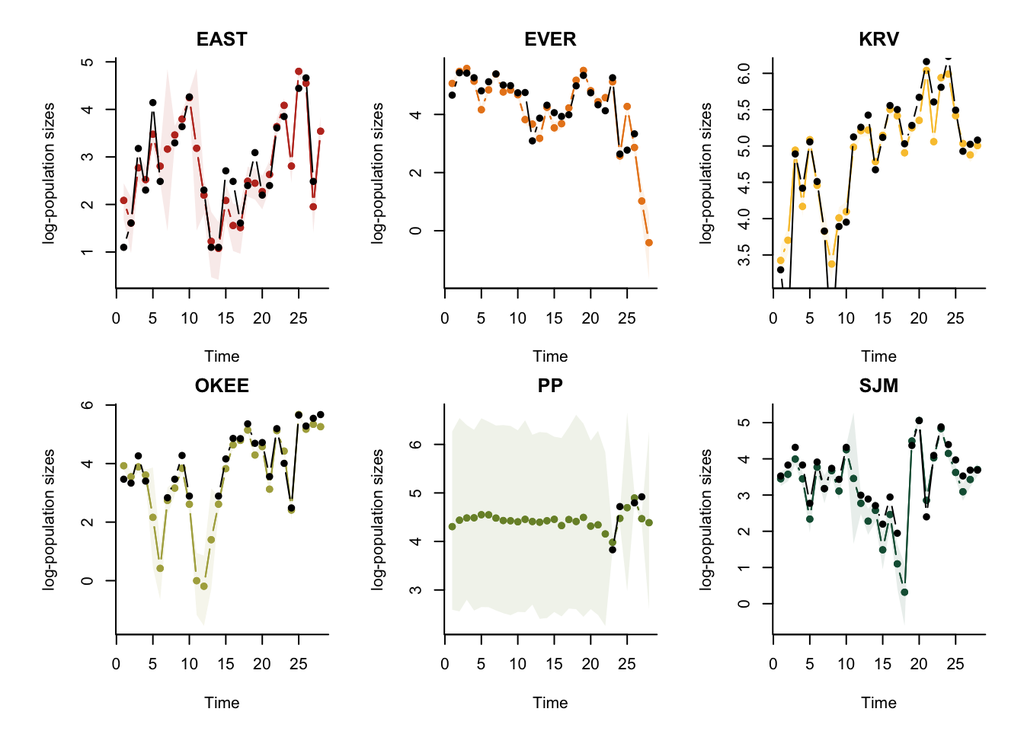

```r
len <- ncol(S4mat)
deme.names <- row.names(S4mat)
# Now we define a color palette for plotting:
cool.palette <- as.vector(met.brewer("Homer2",6))

names.quants <- substr(colnames(Kalman.quants), start=1, stop=3)
X1s <- Kalman.quants[,which(names.quants=="X[1", arr.ind=TRUE)]
X2s <- Kalman.quants[,which(names.quants=="X[2", arr.ind=TRUE)]
X3s <- Kalman.quants[,which(names.quants=="X[3", arr.ind=TRUE)]
X4s <- Kalman.quants[,which(names.quants=="X[4", arr.ind=TRUE)]
X5s <- Kalman.quants[,which(names.quants=="X[5", arr.ind=TRUE)]
X6s <- Kalman.quants[,which(names.quants=="X[6", arr.ind=TRUE)]

par(mfrow=c(2,3), oma=c(1,1,1,1), mar=c(4,5,2,1))
plot(1:len, X1s[2,], pch=16, type="b", col=cool.palette[1],
     ylim=c(min(X1s),max(X1s)),
     main =deme.names[1],
     xlab="Time",
     ylab="log-population sizes", bty="l")
polygon(c(1:len,rev(1:len)), c(X1s[1,],rev(X1s[3,])),
        col=scales::alpha(cool.palette[1],0.1), border=NA)
points(1:len, X1s[2,],pch=16, type="b", col=cool.palette[1])
points(1:len, log(S4mat[1,]),pch=16, type="b", col="black")

plot(1:len, X2s[2,], pch=16, type="b", col=cool.palette[2],
     ylim=c(min(X2s),max(X2s)),
     main =deme.names[2],
     xlab="Time",
     ylab="log-population sizes", bty="l")
polygon(c(1:len,rev(1:len)), c(X2s[1,],rev(X2s[3,])),
        col=scales::alpha(cool.palette[2],0.1), border=NA)
points(1:len, X2s[2,],pch=16, type="b", col=cool.palette[2])
points(1:len, log(S4mat[2,]),pch=16, type="b", col="black")

plot(1:len, X3s[2,], pch=16, type="b", col=cool.palette[3],
     ylim=c(min(X3s),max(X3s)),
     main =deme.names[3],
     xlab="Time",
     ylab="log-population sizes", bty="l")
polygon(c(1:len,rev(1:len)), c(X3s[1,],rev(X3s[3,])),
        col=scales::alpha(cool.palette[3],0.1), border=NA)
points(1:len, X3s[2,],pch=16, type="b", col=cool.palette[3])
points(1:len, log(S4mat[3,]),pch=16, type="b", col="black")


plot(1:len, X4s[2,], pch=16, type="b", col=cool.palette[4],
     ylim=c(min(X4s),max(X4s)),
     main =deme.names[4],
     xlab="Time",
     ylab="log-population sizes", bty="l")
polygon(c(1:len,rev(1:len)), c(X4s[1,],rev(X4s[3,])),
        col=scales::alpha(cool.palette[4],0.1), border=NA)
points(1:len, X4s[2,],pch=16, type="b", col=cool.palette[4])
points(1:len, log(S4mat[4,]),pch=16, type="b", col="black")


plot(1:len, X5s[2,], pch=16, type="b", col=cool.palette[5],
     ylim=c(min(X5s),max(X5s)),
     main =deme.names[5],
     xlab="Time",
     ylab="log-population sizes", bty="l")
polygon(c(1:len,rev(1:len)), c(X5s[1,],rev(X5s[3,])),
        col=scales::alpha(cool.palette[5],0.1), border=NA)
points(1:len, X5s[2,],pch=16, type="b", col=cool.palette[5])
points(1:len, log(S4mat[5,]),pch=16, type="b", col="black")

plot(1:len, X6s[2,], pch=16, type="b", col=cool.palette[6],
     ylim=c(min(X6s),max(X6s)),
     main =deme.names[6],
     xlab="Time",
     ylab="log-population sizes", bty="l")
polygon(c(1:len,rev(1:len)), c(X6s[1,],rev(X6s[3,])),
        col=scales::alpha(cool.palette[6],0.1), border=NA)
points(1:len, X6s[2,],pch=16, type="b", col=cool.palette[6])
points(1:len, log(S4mat[6,]),pch=16, type="b", col="black")
```

```r
#![Kalman estimates vs. log-observed abundances from a simple Poisson sampling error model](Kalman-VsObserved-PoissonSampling.JPEG)<br>
```

Just to check, how does the estimate of the total population size from Mark-recapture compares to the sum of the exponential of the Kalman estimates?

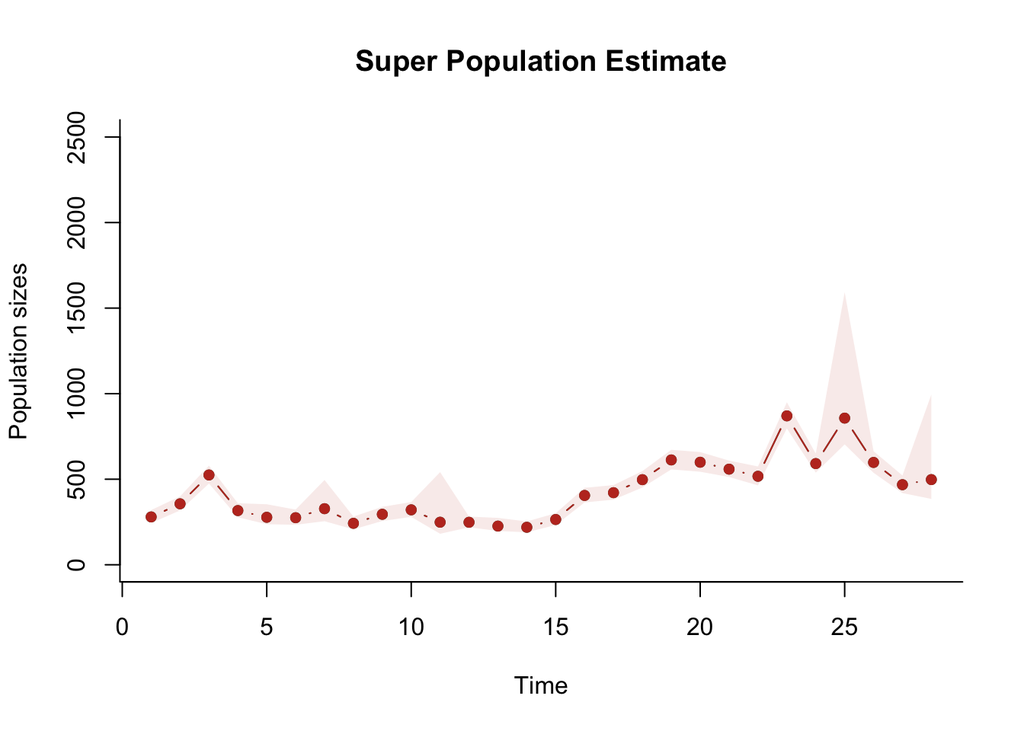

```r
names.quants2 <- substr(colnames(Kalman.quants), start=1, stop=6)
Nhats1 <- Kalman.quants[,which(names.quants2=="Nhat[1", arr.ind=TRUE)]
Nhats2 <- Kalman.quants[,which(names.quants2=="Nhat[2", arr.ind=TRUE)]
Nhats3 <- Kalman.quants[,which(names.quants2=="Nhat[3", arr.ind=TRUE)]
Nhats4 <- Kalman.quants[,which(names.quants2=="Nhat[4", arr.ind=TRUE)]
Nhats5 <- Kalman.quants[,which(names.quants2=="Nhat[5", arr.ind=TRUE)]
Nhats5[1:3,1:22] <- 0
Nhats6 <- Kalman.quants[,which(names.quants2=="Nhat[6", arr.ind=TRUE)]

NsLCL <- Nhats1[1,] + Nhats2[1,] + Nhats3[1,] + Nhats4[1,] + Nhats5[1,] + Nhats6[1,]
NsMLE <- Nhats1[2,] + Nhats2[2,] + Nhats3[2,] + Nhats4[2,] + Nhats5[2,] + Nhats6[2,]
NsUCL <- Nhats1[3,] + Nhats2[3,] + Nhats3[3,] + Nhats4[3,] + Nhats5[3,] + Nhats6[3,]

par(mfrow=c(1,1))
plot(1:len, NsMLE, pch=16, type="b", col=cool.palette[6],
     main ="Super Population Estimate",
     ylim= c(0,2500),
     xlab="Time",
     ylab="Population sizes", bty="l")
polygon(c(1:len,rev(1:len)), c(NsLCL,rev(NsUCL)),
        col=scales::alpha(cool.palette[1],0.1), border=NA)
points(1:len, NsMLE,pch=16, type="b", col=cool.palette[1])
```

```r
### Mark-recapture

mark.dat <- read.csv("Code/2024_1997_popsize_ci.csv", header=TRUE)
names(mark.dat)
```

```
## [1] "X"        "Year"     "Nsuper"   "SE"       "SuperLCL" "SuperUCL"
```

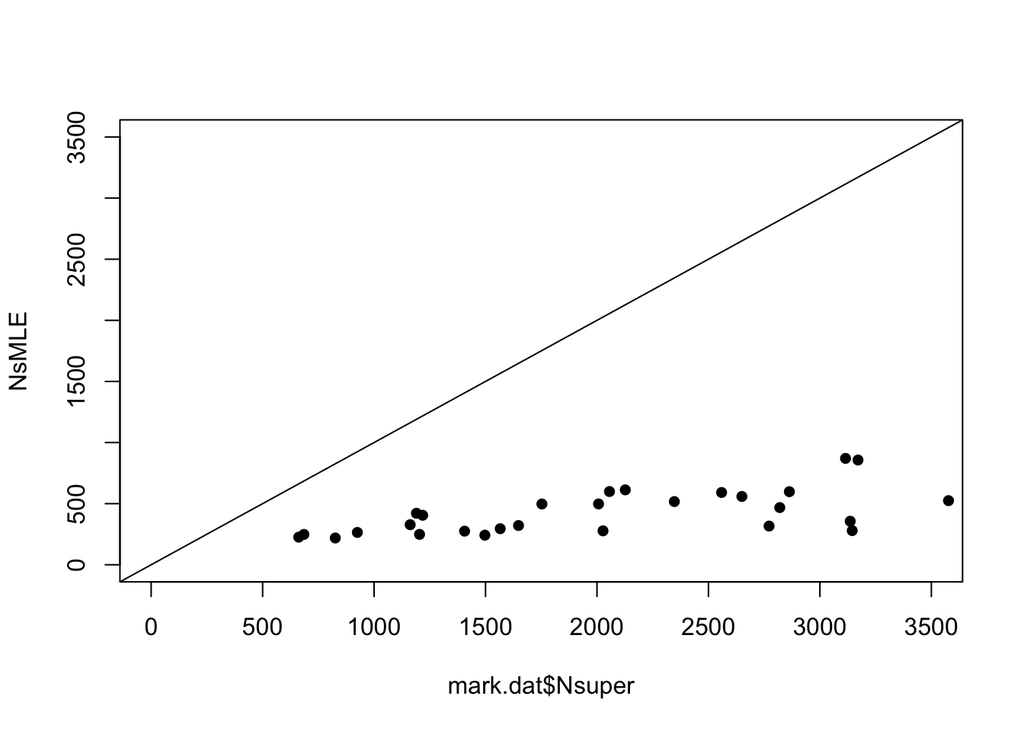

```r
plot(mark.dat$Nsuper,NsMLE, pch=16, xlim=c(0,3500), ylim=c(0,3500))
abline(a=0,b=1)
```

```r
#write.csv(cbind(NsLCL,NsMLE,NsUCL), file="Code/TimeSeriesMLEs.csv")
```

Now we write a model that includes an extra parameter for detectability:

```r
MGSS_DC4.0 <- function(){
  ##### Priors (no cloning)
  lmuvec    ~ dmnorm(mupmean, muprec)
  lthetavec ~ dmnorm(lthetamean, lthetaprec)
  lsigmasq ~ dnorm(0, 1)
  #mig ~ dbeta(2,2)
  mig.near ~ dnorm(0,1)
  mig.far ~ dnorm(0,1)
  #ldetectp ~ dnorm(0,1)
  #detectp <- 1/(1+exp(-ldetectp))

  sigmasq <- exp(lsigmasq)
  for(pp in 1:p){
    muvec[pp] <- exp(lmuvec[pp])
    thetavec[pp] <- exp(lthetavec[pp])
    cvec[pp] <- exp(-thetavec[pp])
  }

  Sigma <- (1/sigmasq)*Ip

  for(m in 1:p){
    for(n in 1:p){
      B[m,n] <- ifelse((m==n),cvec[m],ifelse(
        (m==step.stone[m,1])&&(n==step.stone[m,2]),
        dinvmat[m,n]*mig.near,dinvmat[m,n]*mig.far)
      )
    }
  }

  A[1:p]  <- (Ip - B[1:p,1:p])%*%muvec

  for(k in 1:K){
    ##### ---- Likelihood (data cloning) ---- #####
    X[1:p,1,k] ~ dmnorm(muvec, Sigma) #muvec + beta*water[,1]
    for(h in 1:p){
      N4[h,1,k] ~ dpois(detectp[1]*exp(X[h,1,k]))
      N5[h,1,k] ~ dpois(detectp[1]*exp(X[h,1,k]))
      N6[h,1,k] ~ dpois(detectp[1]*exp(X[h,1,k]))
    }
    for( i in 2:qp1){
      ## Process error
      X[1:p,i,k]  ~ dmnorm(A[1:p] + B[1:p,1:p]%*%X[1:p,(i-1),k], Sigma); #A[1:p] + beta*water[,1] + B[...]
      for(j in 1:p){
        N4[j,i,k]  ~ dpois(detectp[i]*exp(X[j,i,k])) ## Observation error
        N5[j,i,k]  ~ dpois(detectp[i]*exp(X[j,i,k])) ## Observation error
        N6[j,i,k]  ~ dpois(detectp[i]*exp(X[j,i,k])) ## Observation error
      }
    }
  }
}
```

Next, we import the matrix of detectability estimates over the years:

```r
detectabilities <- read.csv("Code/detectability.csv")

phats <- detectabilities[-(1:4),1]
```

And getting the data to do the data cloning:

```r
data4dclone <- list(K=1,
                    N4=dcdim(array(S4mat,dim=c(p,ncol(S4mat),1))),
                    N5=dcdim(array(S5mat,dim=c(p,ncol(S5mat),1))),
                    N6=dcdim(array(S6mat,dim=c(p,ncol(S6mat),1))),
                    qp1=ncol(S4mat),
                    p=p,
                    mupmean=rep(6,p),
                    muprec=(1/3)*diag(p),
                    lthetamean = rep(0.5,p),
                    lthetaprec =  10*diag(p),
                    Ip =  diag(p),
                    dinvmat = dinvmat,
                    step.stone = matrix(c(1,4,2,4,3,5,4,1,5,3,6,3),
                                        nrow=6,ncol=2,byrow=TRUE),
                    detectp=phats
                    )
```

Finally, we set up the number of clones, the MCMC chains, which parameters to sample, and fit the data cloning model (it takes some time, so it is in `eval = FALSE` at this moment).

```r
#cl.seq <- c(1,4,8,16);
cl.seq <- c(20)
n.iter<-100000;n.adapt<-50000;n.update<-100;thin<-10;n.chains<-3;

out.parms <- c("muvec", "cvec", "mig.near", "mig.far", "sigmasq", "A")
mgssdclone2<- dc.fit(data4dclone,
                     params=out.parms,
                     model=MGSS_DC4.0,
                     n.clones=cl.seq,
                     multiply="K",
                     unchanged = c("qp1","p","mupmean","muprec",
                      "step.stone", "lthetamean","lthetaprec", "Ip","dinvmat","detectp"),
                     n.chains = n.chains,
                     n.adapt=n.adapt,
                     n.update=n.update,
                     n.iter = n.iter,
                     thin=thin,
                     inits=myinits)
saveRDS(mgssdclone2, "Code/mgssdclone2.RDS")
```

Let’s check this model:

```r
mgssdclone2 <- readRDS("Code/mgssdclone2.RDS")
dcdiag(mgssdclone2)
```

|  | n.clones | lambda.max | ms.error | r.squared | r.hat |
| --- | --- | --- | --- | --- | --- |
| 1 | 20 | 0.5834306 | 37.72474 | 0.1071004 | 1.005418 |

```r
summary(mgssdclone2)
```

```
##
## Iterations = 50110:150100
## Thinning interval = 10
## Number of chains = 3
## Sample size per chain = 10000
## Number of clones = 20
##
## 1. Empirical mean and standard deviation for each variable,
##    plus standard error of the mean:
##
##             Mean      SD  DC SD  Naive SE Time-series SE R hat
## A[1]      2.1154 0.17126 0.7659 0.0009888      0.0014679 1.000
## A[2]      1.0405 0.15121 0.6762 0.0008730      0.0016021 1.000
## A[3]      3.3792 0.40434 1.8083 0.0023345      0.0040558 1.000
## A[4]      2.3199 0.18495 0.8271 0.0010678      0.0016425 1.000
## A[5]      4.4240 0.37376 1.6715 0.0021579      0.0057293 1.000
## A[6]      2.5978 0.17636 0.7887 0.0010182      0.0014992 1.001
## cvec[1]   0.4905 0.03732 0.1669 0.0002154      0.0003782 1.000
## cvec[2]   0.8302 0.02827 0.1264 0.0001632      0.0003539 1.000
## cvec[3]   0.4125 0.06515 0.2914 0.0003762      0.0006550 1.000
## cvec[4]   0.5245 0.02973 0.1329 0.0001716      0.0003190 1.000
## cvec[5]   0.1478 0.07035 0.3146 0.0004062      0.0010520 1.000
## cvec[6]   0.4377 0.03490 0.1561 0.0002015      0.0003554 1.001
## mig.far   0.4022 0.69134 3.0917 0.0039914      0.0044198 1.000
## mig.near -3.9646 0.74709 3.3411 0.0043134      0.0045809 1.000
## muvec[1]  3.6217 0.08001 0.3578 0.0004620      0.0008827 1.001
## muvec[2]  5.3226 0.19933 0.8915 0.0011509      0.0025227 1.000
## muvec[3]  5.6906 0.06953 0.3110 0.0004015      0.0006664 1.000
## muvec[4]  4.4536 0.08430 0.3770 0.0004867      0.0008723 1.000
## muvec[5]  5.0916 0.11490 0.5139 0.0006634      0.0028148 1.005
## muvec[6]  4.1503 0.07096 0.3173 0.0004097      0.0007328 1.000
## sigmasq   0.9123 0.02780 0.1243 0.0001605      0.0002158 1.000
##
## 2. Quantiles for each variable:
##
##              2.5%      25%     50%     75%   97.5%
## A[1]      1.78142  2.00107  2.1141  2.2295  2.4554
## A[2]      0.75228  0.93666  1.0376  1.1413  1.3424
## A[3]      2.60119  3.10423  3.3754  3.6519  4.1747
## A[4]      1.95628  2.19573  2.3195  2.4444  2.6849
## A[5]      3.60624  4.18509  4.4589  4.6989  5.0508
## A[6]      2.24749  2.47982  2.5991  2.7165  2.9404
## cvec[1]   0.41622  0.46559  0.4906  0.5157  0.5626
## cvec[2]   0.77308  0.81120  0.8312  0.8498  0.8829
## cvec[3]   0.28460  0.36918  0.4128  0.4566  0.5376
## cvec[4]   0.46559  0.50464  0.5247  0.5448  0.5819
## cvec[5]   0.03433  0.09499  0.1403  0.1926  0.3015
## cvec[6]   0.36907  0.41399  0.4376  0.4616  0.5050
## mig.far  -0.95320 -0.06413  0.4061  0.8643  1.7718
## mig.near -5.42975 -4.46477 -3.9670 -3.4566 -2.5081
## muvec[1]  3.46463  3.56761  3.6219  3.6757  3.7792
## muvec[2]  4.95951  5.18498  5.3120  5.4507  5.7437
## muvec[3]  5.54893  5.64515  5.6922  5.7371  5.8227
## muvec[4]  4.29003  4.39626  4.4540  4.5089  4.6220
## muvec[5]  4.86594  5.01452  5.0914  5.1692  5.3151
## muvec[6]  4.01376  4.10148  4.1501  4.1981  4.2913
## sigmasq   0.85981  0.89316  0.9116  0.9306  0.9682
```

```r
confint(mgssdclone2)
```

```
##                2.5 %    97.5 %
## A[1]       0.6142769 3.6165684
## A[2]      -0.2848524 2.3659104
## A[3]      -0.1649833 6.9233298
## A[4]       0.6987998 3.9410102
## A[5]       1.1479102 7.7001748
## A[6]       1.0519731 4.1436407
## cvec[1]    0.1634521 0.8176041
## cvec[2]    0.5823657 1.0780108
## cvec[3]   -0.1585952 0.9835620
## cvec[4]    0.2638959 0.7850303
## cvec[5]   -0.4688768 0.7644464
## cvec[6]    0.1317610 0.7435671
## mig.far   -5.6575339 6.4618964
## mig.near -10.5130770 2.5838330
## muvec[1]   2.9203416 4.3230214
## muvec[2]   3.5754092 7.0698355
## muvec[3]   5.0810895 6.3000468
## muvec[4]   3.7146693 5.1925180
## muvec[5]   4.0844428 6.0987058
## muvec[6]   3.5283735 4.7722852
## sigmasq    0.6686958 1.1559993
```

Now let’s save the MLEs and predict the dynamic of the population for each region with the Kalman filter estimates

```r
mlescentrdist2 <- summary(mgssdclone2)[[1]]
mles4kalman2 <- mlescentrdist2[,1]
mles4kalman2
```

```
##       A[1]       A[2]       A[3]       A[4]       A[5]       A[6]    cvec[1]
##  2.1154227  1.0405290  3.3791732  2.3199050  4.4240425  2.5978069  0.4905281
##    cvec[2]    cvec[3]    cvec[4]    cvec[5]    cvec[6]    mig.far   mig.near
##  0.8301882  0.4124834  0.5244631  0.1477848  0.4376640  0.4021812 -3.9646220
##   muvec[1]   muvec[2]   muvec[3]   muvec[4]   muvec[5]   muvec[6]    sigmasq
##  3.6216815  5.3226223  5.6905682  4.4535937  5.0915743  4.1503294  0.9123476
```

```r
avec4kalman2 <- mles4kalman2[1:6]
cvec4kalman2 <- mles4kalman2[7:12]
mig.far4kalman2  <- mles4kalman2[13]
mig.near4kalman2 <- mles4kalman2[14]
muvec4kalman2 <- mles4kalman2[15:20]
sigsq4kalman2 <- mles4kalman2[21]
# Retrieve the detect probability now as well
```

And the new Kalman estimates sampler:

```r
MGSS_KALMAN3.0 <- function(){

  A  <- (Ip - B)%*%muvec
  Sigma <- (1/sigmasq)*Ip

  ##### ---- Likelihood ---- #####
  X[1:p,1] ~ dmnorm(muvec, Sigma)
  for(h in 1:p){
    N4[h,1] ~ dpois(detectp[1]*exp(X[h,1]))
    N5[h,1] ~ dpois(detectp[1]*exp(X[h,1]))
    N6[h,1] ~ dpois(detectp[1]*exp(X[h,1]))
  }
  for( i in 2:qp1){
    ## Process error
    X[1:p,i]  ~ dmnorm(A + B%*%X[1:p,(i-1)], Sigma);
    for(j in 1:p){
      N4[j,i]  ~ dpois(detectp[i]*exp(X[j,i])) ## Observation error
      N5[j,i]  ~ dpois(detectp[i]*exp(X[j,i])) ## Observation error
      N6[j,i]  ~ dpois(detectp[i]*exp(X[j,i])) ## Observation error
    }
  }

  for(i in 1:p){
    for(j in 1:qp1){
      Nhat[i,j] <- exp(X[i,j])
    }
  }

}
```

Bundling data for the new Kalman estimates:

```r
step.stone <- matrix(c(1,4,2,4,3,5,4,1,5,3,6,3),
                     nrow=6,
                     ncol=2,
                     byrow=TRUE)
step.stone
```

```
##      [,1] [,2]
## [1,]    1    4
## [2,]    2    4
## [3,]    3    5
## [4,]    4    1
## [5,]    5    3
## [6,]    6    3
```

```r
B2 <- matrix(0,p,p)

for(m in 1:p){
  for(n in 1:p){
    B2[m,n] <- ifelse((m==n),cvec4kalman2[m],ifelse(
      (m==step.stone[m,1])&&(n==step.stone[m,2]),
      dinvmat[m,n]*mig.near4kalman2,dinvmat[m,n]*mig.far4kalman2)
    ) #

  }
}

print(B2)
```

```
##              [,1]         [,2]         [,3]         [,4]          [,5]
## [1,]  0.490528071 0.0037539316  0.002853786 -0.074302297  0.0011611988
## [2,]  0.003753932 0.8301882484  0.001917696 -0.040055993  0.0009535761
## [3,]  0.002853786 0.0019176965  0.412483386  0.003574118 -0.0186699598
## [4,] -0.074302297 0.0040633806  0.003574118  0.524463132  0.0012382198
## [5,]  0.001161199 0.0009535761 -0.018669960  0.001238220  0.1477847874
## [6,]  0.004453045 0.0021669364 -0.056167257  0.004433068  0.0015567301
##             [,6]
## [1,] 0.004453045
## [2,] 0.002166936
## [3,] 0.005697748
## [4,] 0.004433068
## [5,] 0.001556730
## [6,] 0.437664037
```

```r
data4kalman2 <- list(N4=S4mat,
                    N5=S5mat,
                    N6=S6mat,
                    qp1=ncol(S4mat),
                    p=p,
                    Ip =  diag(p),
                    muvec = muvec4kalman2,
                    sigmasq = sigsq4kalman2,
                    B=B2,
                    detectp = phats
)
#str(data4kalman2)
```

And finally set up and sample the Kalman estimates

```r
n.iter<-100000
n.adapt<-1000
n.update<-100
thin<-10
n.chains<-3

out.parms <- c("X","Nhat")
kalman.mcmcw2 <- jags.fit(data4kalman2,
                         params=out.parms,
                         model=MGSS_KALMAN3.0,
                         n.chains = n.chains,
                         n.adapt=n.adapt,
                         n.update=n.update,
                         n.iter = n.iter,
                         thin=thin)
```

And then, bring back the data to see the population trajectories in each region.

```r
Xkalman2 <-  do.call(rbind, kalman.mcmcw2)
Kalman.quants2 <- apply(Xkalman2, 2, FUN=function(x){quantile(x, probs=c(0.025,0.5,0.975))})
```

Here, we can plot the new Kalman estimates, with CI.

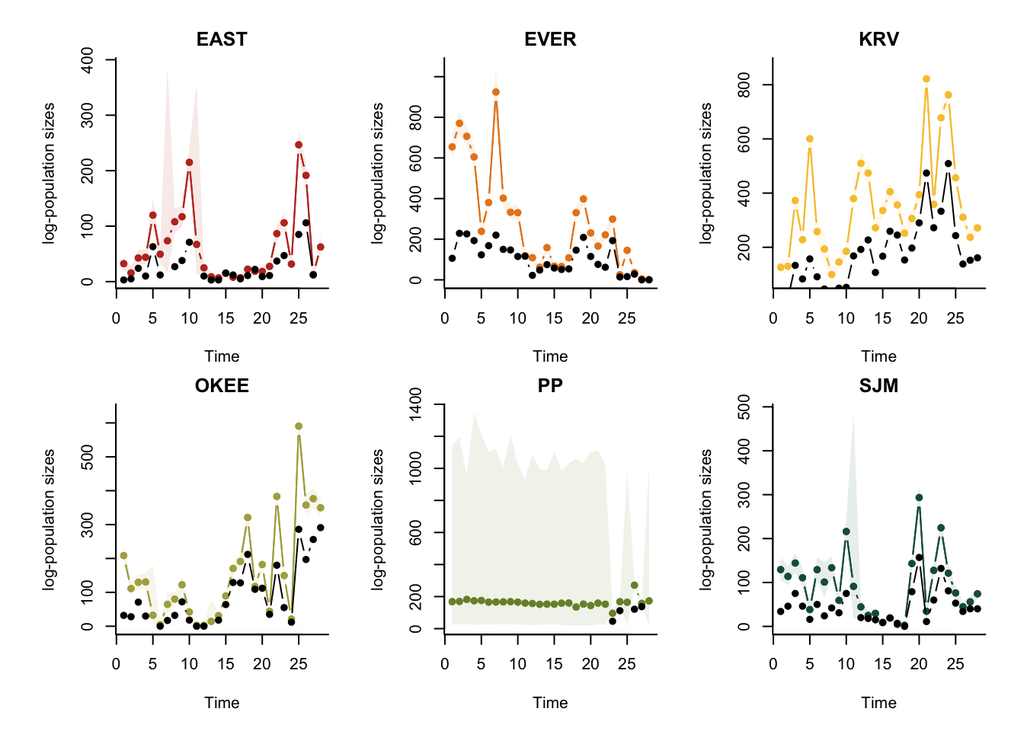

```r
len <- ncol(S4mat)
deme.names <- row.names(S4mat)
# Now we define a color palette for plotting:
cool.palette <- as.vector(met.brewer("Homer2",6))

names.quants2 <- substr(colnames(Kalman.quants2), start=1, stop=3)
X1s2 <- Kalman.quants2[,which(names.quants2=="X[1", arr.ind=TRUE)]
X2s2 <- Kalman.quants2[,which(names.quants2=="X[2", arr.ind=TRUE)]
X3s2 <- Kalman.quants2[,which(names.quants2=="X[3", arr.ind=TRUE)]
X4s2 <- Kalman.quants2[,which(names.quants2=="X[4", arr.ind=TRUE)]
X5s2 <- Kalman.quants2[,which(names.quants2=="X[5", arr.ind=TRUE)]
X6s2 <- Kalman.quants2[,which(names.quants2=="X[6", arr.ind=TRUE)]

X1s2 <- exp(X1s2)
X2s2 <- exp(X2s2)
X3s2 <- exp(X3s2)
X4s2 <- exp(X4s2)
X5s2 <- exp(X5s2)
X6s2 <- exp(X6s2)


par(mfrow=c(2,3), oma=c(1,1,1,1), mar=c(4,5,2,1))
plot(1:len, X1s2[2,], pch=16, type="b", col=cool.palette[1],
     ylim=c(min(X1s2),max(X1s2)),
     main =deme.names[1],
     xlab="Time",
     ylab="log-population sizes", bty="l")
polygon(c(1:len,rev(1:len)), c(X1s2[1,],rev(X1s2[3,])),
        col=scales::alpha(cool.palette[1],0.1), border=NA)
points(1:len, X1s2[2,],pch=16, type="b", col=cool.palette[1])
points(1:len, S4mat[1,],pch=16, type="b", col="black")

plot(1:len, X2s2[2,], pch=16, type="b", col=cool.palette[2],
     ylim=c(min(X2s2),max(X2s2)),
     main =deme.names[2],
     xlab="Time",
     ylab="log-population sizes", bty="l")
polygon(c(1:len,rev(1:len)), c(X2s2[1,],rev(X2s2[3,])),
        col=scales::alpha(cool.palette[2],0.1), border=NA)
points(1:len, X2s2[2,],pch=16, type="b", col=cool.palette[2])
points(1:len, S4mat[2,],pch=16, type="b", col="black")

plot(1:len, X3s2[2,], pch=16, type="b", col=cool.palette[3],
     ylim=c(min(X3s2),max(X3s2)),
     main =deme.names[3],
     xlab="Time",
     ylab="log-population sizes", bty="l")
polygon(c(1:len,rev(1:len)), c(X3s2[1,],rev(X3s2[3,])),
        col=scales::alpha(cool.palette[3],0.1), border=NA)
points(1:len, X3s2[2,],pch=16, type="b", col=cool.palette[3])
points(1:len, S4mat[3,],pch=16, type="b", col="black")


plot(1:len, X4s2[2,], pch=16, type="b", col=cool.palette[4],
     ylim=c(min(X4s2),max(X4s2)),
     main =deme.names[4],
     xlab="Time",
     ylab="log-population sizes", bty="l")
polygon(c(1:len,rev(1:len)), c(X4s2[1,],rev(X4s2[3,])),
        col=scales::alpha(cool.palette[4],0.1), border=NA)
points(1:len, X4s2[2,],pch=16, type="b", col=cool.palette[4])
points(1:len, S4mat[4,],pch=16, type="b", col="black")


plot(1:len, X5s2[2,], pch=16, type="b", col=cool.palette[5],
     ylim=c(min(X5s2),max(X5s2)),
     main =deme.names[5],
     xlab="Time",
     ylab="log-population sizes", bty="l")
polygon(c(1:len,rev(1:len)), c(X5s2[1,],rev(X5s2[3,])),
        col=scales::alpha(cool.palette[5],0.1), border=NA)
points(1:len, X5s2[2,],pch=16, type="b", col=cool.palette[5])
points(1:len, S4mat[5,],pch=16, type="b", col="black")

plot(1:len, X6s2[2,], pch=16, type="b", col=cool.palette[6],
     ylim=c(min(X6s2),max(X6s2)),
     main =deme.names[6],
     xlab="Time",
     ylab="log-population sizes", bty="l")
polygon(c(1:len,rev(1:len)), c(X6s2[1,],rev(X6s2[3,])),
        col=scales::alpha(cool.palette[6],0.1), border=NA)
points(1:len, X6s2[2,],pch=16, type="b", col=cool.palette[6])
points(1:len, S4mat[6,],pch=16, type="b", col="black")
```

```r
#![Kalman estimates vs. log-observed abundances from a simple Poisson sampling error model](Kalman-VsObserved-PoissonSampling-pdetect.JPEG)<br>
```

Just to check, how does the estimate of the total population size from Mark-recapture compares to the sum of the exponential of the Kalman estimates?

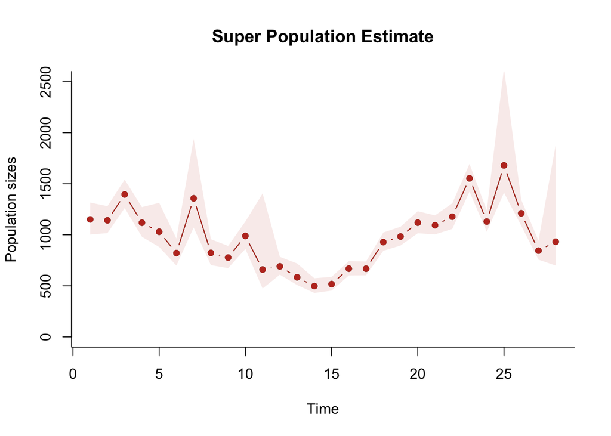

```r
names.quants4 <- substr(colnames(Kalman.quants2), start=1, stop=6)
Nhats1.2 <- Kalman.quants2[,which(names.quants4=="Nhat[1", arr.ind=TRUE)]
Nhats2.2 <- Kalman.quants2[,which(names.quants4=="Nhat[2", arr.ind=TRUE)]
Nhats3.2 <- Kalman.quants2[,which(names.quants4=="Nhat[3", arr.ind=TRUE)]
Nhats4.2 <- Kalman.quants2[,which(names.quants4=="Nhat[4", arr.ind=TRUE)]
Nhats5.2 <- Kalman.quants2[,which(names.quants4=="Nhat[5", arr.ind=TRUE)]
Nhats5.2[1:3,1:22] <- 0
Nhats6.2 <- Kalman.quants2[,which(names.quants4=="Nhat[6", arr.ind=TRUE)]

NsLCL.2 <- Nhats1.2[1,] + Nhats2.2[1,] + Nhats3.2[1,] + Nhats4.2[1,] + Nhats5.2[1,] + Nhats6.2[1,]
NsMLE.2 <- Nhats1.2[2,] + Nhats2.2[2,] + Nhats3.2[2,] + Nhats4.2[2,] + Nhats5.2[2,] + Nhats6.2[2,]
NsUCL.2 <- Nhats1.2[3,] + Nhats2.2[3,] + Nhats3.2[3,] + Nhats4.2[3,] + Nhats5.2[3,] + Nhats6.2[3,]

par(mfrow=c(1,1))
plot(1:len, NsMLE.2, pch=16, type="b", col=cool.palette[6],
     main ="Super Population Estimate",
     ylim= c(0,2500),
     xlab="Time",
     ylab="Population sizes", bty="l")
polygon(c(1:len,rev(1:len)), c(NsLCL.2,rev(NsUCL.2)),
        col=scales::alpha(cool.palette[1],0.1), border=NA)
points(1:len, NsMLE.2,pch=16, type="b", col=cool.palette[1])
```

```r
### Mark-recapture

mark.dat <- read.csv("Code/2024_1997_popsize_ci.csv", header=TRUE)

names(mark.dat)
```

```
## [1] "X"        "Year"     "Nsuper"   "SE"       "SuperLCL" "SuperUCL"
```

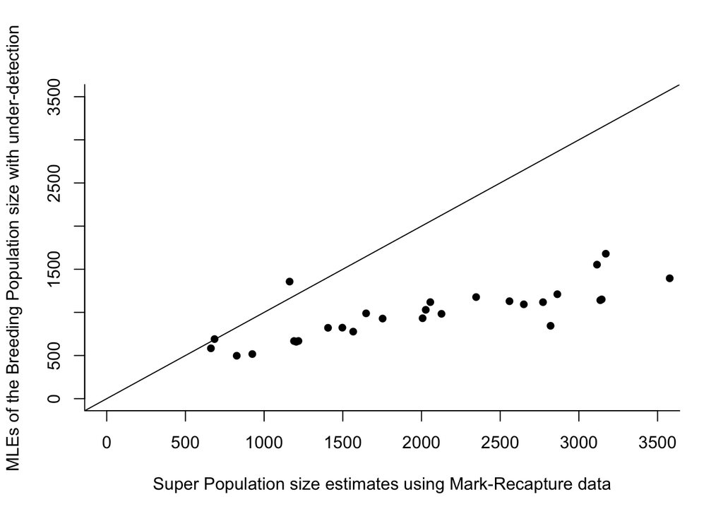

```r
plot(mark.dat$Nsuper,NsMLE.2, pch=16, xlim=c(0,3500), ylim=c(0,3500),
     xlab=c("Super Population size estimates using Mark-Recapture data"),
     ylab="MLEs of the Breeding Population size with under-detection",
     bty="l")
abline(a=0,b=1)
```

```r
write.csv(cbind(NsLCL.2,NsMLE.2,NsUCL.2), file="Code/TimeSeriesMLEs-pdetect.csv")

#save.image("Code/SamplingError.RData")
```

# 1 Population viability analysis: short, medium and long term projections per deme

With the population dynamics model parameter estimates, we can now focus on building a function to compute the same probabilities for any value of a change in the stationary mean and any proportion of the past average population abundances `E.N`.

To do this, we now need to compute the year-wise cumulative probability of dropping below an arbitrarily low critical number. Starting at the current population size, this number tracks the probability that the population will drop below a critical number anytime between the present time and every subsequent year, for as many years we simulated the population forward in time. Here we simulated only 10 years forward in time thus sticking with short-term forecasting. The critical abundance used in these simulations was conservatively set as 75% the estimated mean of the stationary distribution for every deme. This quantity then becomes our standard population viability threshold for every deme in our simulations for this first part of the report.

The deterministic breeding carrying capacities for each deme are given by exponentiating the vector of estimated means of the Normal stationary distribution in the log-scale:

```r
ks <- exp(muvec4kalman2)
names(ks) <- row.names(S4mat)
print(ks)
```

```
##      EAST      EVER       KRV      OKEE        PP       SJM
##  37.40040 204.92055 296.06178  85.93521 162.64572  63.45490
```

In the population size scale, the mean of the abundances is given by the expected value `E.N` of the log-normal stationary distribution for every deme. This value is bigger always than the deterministic carrying capacity. This expected value however, is not simply the exponentiated mean of the stationary distribution in the logarithmic scale (*i.e.* the deterministic carrying capacities). This expected value is computed easily since with the model ML estmates we can in turn estimate of the stationary variance for every deme using equation 17 in Ives et al 2003:

```r
Ip <- diag(p)
Sigma <- (1/sigsq4kalman2)*Ip

Ipsq <- diag(p*p)
vec.Vinf <- solve(Ipsq - kronecker(B,B))%*%as.vector(Sigma)
Vinf <- matrix(vec.Vinf, nrow=p,ncol=p)
Vars.inf <- diag(Vinf)
names(Vars.inf) <- row.names(S4mat)

E.Ns <- exp(muvec4kalman2 + Vars.inf/2)
names(E.Ns) <- row.names(S4mat)
print(E.Ns)
```

```
##      EAST      EVER       KRV      OKEE        PP       SJM
##  74.91533 742.76100 636.30608 209.18308 285.45543 118.45318
```

Next, we build a time series simulator, starting from a given initial value. The function is primed with the estimated true, latent final log-abundances at each deme and the ML estimates of the model parameters. This time series simulator is needed because the probability of the breeding population size dropping below any threshold within a given time interval is computed as the proportion of simulated time series under the same conditions that fall under that same pre-set threshold. This simulator function is done in the log-scale to be able to take advantage of the fast random multivariate number generator:

```r
MVX.sim <- function(xo.vec = c(X1s[2,28],X2s[2,28],X3s[2,28],X4s[2,28],X5s[2,28],X6s[2,28]),
                    theta.list=
                    list(p=p,
                    Ip =  diag(p),
                    muvec = muvec4kalman,
                    sigmasq = sigsq4kalman,
                    B=B),
                    nsteps=5,
                    rnames = row.names(S4mat)){

  p  <- theta.list$p
  Ip <- theta.list$Ip
  muvec <- theta.list$muvec
  sigmasq <- theta.list$sigmasq
  B <- theta.list$B

  A  <- (Ip - B)%*%muvec
  Sigma <- (1/sigmasq)*Ip

  X <- matrix(0,nrow=p,ncol=nsteps)
  X[1:p,1] <- randmvn(n=1,mu.vec=A+B%*%xo.vec, cov.mat=Sigma)

  for( i in 2:nsteps){
    ## Process error
    X[1:p,i] <- randmvn(n=1,mu.vec=A + B%*%X[1:p,(i-1)], cov.mat=Sigma)
  }

  X <- cbind(xo.vec,X)
  row.names(X) <- rnames
  colnames(X) <- 0:nsteps
  return(X)
}
```

```r
p.ext <- function(pct.change=0.9, muvec4kalman=muvec4kalman2, xinits=
                    c(X1s2[2,28],X2s2[2,28],X3s2[2,28],X4s2[2,28],X5s2[2,28],X6s2[2,28]),p=p,
                  sigsq4kalman=sigsq4kalman2,B=B2,S4mat=S4mat,E.Ns=E.Ns,
                  nyears.fwd=10, nsims=100000){

  newmus <- muvec4kalman*pct.change
  sims.list50pct <- list()

  for(i in 1:p){
    sims.list50pct[[i]] <- matrix(0,nrow=nsims,ncol=nyears.fwd+1)
  }
  names(sims.list50pct) <- row.names(S4mat)
  for(i in 1:nsims){

    ith.sim <- MVX.sim(xo.vec = xinits,
                    theta.list=
                    list(p=p,
                      Ip =  diag(p),
                      muvec = newmus,
                      sigmasq = sigsq4kalman,
                      B=B),
                    nsteps=10,
                    rnames = row.names(S4mat))

    sims.list50pct[[1]][i,] <- ith.sim[1,]
    sims.list50pct[[2]][i,] <- ith.sim[2,]
    sims.list50pct[[3]][i,] <- ith.sim[3,]
    sims.list50pct[[4]][i,] <- ith.sim[4,]
    sims.list50pct[[5]][i,] <- ith.sim[5,]
    sims.list50pct[[6]][i,] <- ith.sim[6,]
  }

  ncrit <- E.Ns*0.75 # change here to a desired number
  lcrit <- log(ncrit)
  nsteps <- nyears.fwd
  probs.drop50pct <- matrix(0, nrow=6,ncol=nsteps)
  rownames(probs.drop50pct) <- row.names(S4mat)
  for(i in 1:6){

    simsmat <- sims.list50pct[[i]] # drop the initial log pop size

    for(j in 2:(nsteps+1)){

      jthsubmat <- simsmat[,1:j]

      probs.drop50pct[i,(j-1)] <- sum(jthsubmat<lcrit[i])/(nrow(jthsubmat)*ncol(jthsubmat))
    }
  }
  return(probs.drop50pct)
}
```

And so now we compute the probabilities of dropping below `E.N` sometime in the next $1,2,3,\dots,10$ years assuming a percent change in the growth rate from $+50\%$ to $-50\%$, by steps of $10\%$:

```r
probs.change.list <- list()
changes <- seq(1.5,0.5, by=-0.1)
nchanges <- length(changes)

for(i in 1:nchanges){

  probs.change.list[[i]] <- p.ext(pct.change=changes[i], muvec4kalman=muvec4kalman2, xinits=
                    c(X1s2[2,28],X2s2[2,28],X3s2[2,28],X4s2[2,28],X5s2[2,28],X6s2[2,28]),p=p,
                  sigsq4kalman=sigsq4kalman2,B=B2,S4mat=S4mat,E.Ns=E.Ns,
                  nyears.fwd=10, nsims=100000)

}
names(probs.change.list) <- as.character(changes)

print(probs.change.list)


saveRDS(probs.change.list, "Code/probschangelist.RDS")
```

Once these probabilities are computed we are ready to plot them in a single graph:

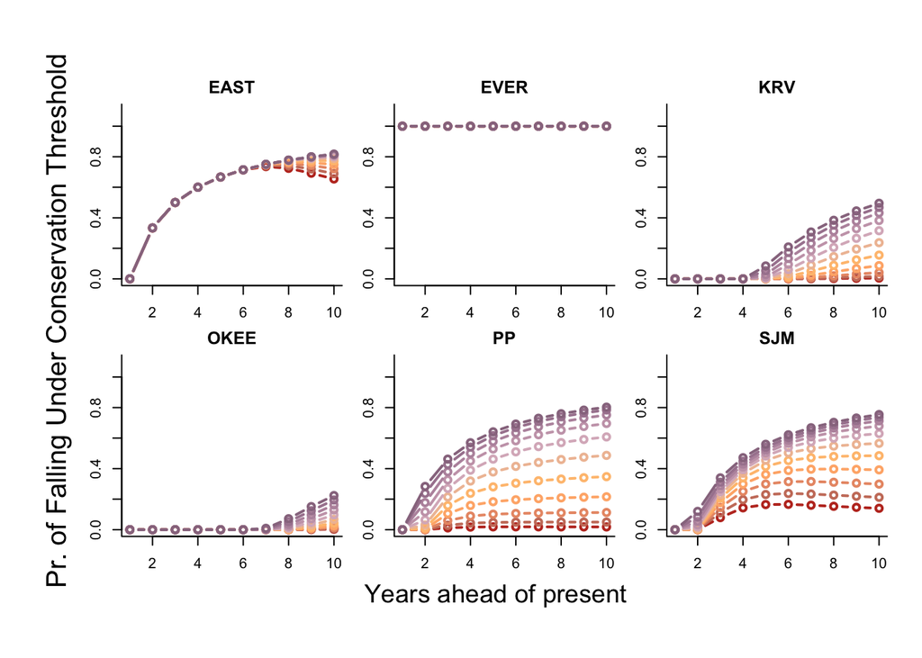

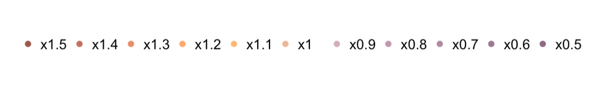

Magnitude of change

```r
probs.change.list <- readRDS("Code/probschangelist.RDS")
changes <- seq(1.5,0.5, by=-0.1)
nchanges <- length(changes)

cool.palette2 <- as.vector(met.brewer("Morgenstern",nchanges)) #
cool.palette2 <- rev(cool.palette2)
nsteps <- ncol(probs.change.list[[1]])

leg.lab <- paste0("x",changes)
cex.leg <- 0.8

par(mfrow=c(2,3),oma=c(5,5,4,1), mar=c(2,2,2,1))

#par(mfrow=c(1,1))
plot(1:nsteps,probs.change.list[[1]][1,], type="b", col=cool.palette[1], lwd=2, ylim=c(0,1.1), bty="l",
     xlab="", ylab="", cex.lab=1.25,
     main=row.names(S4mat)[1])
for(i in 2:nchanges){
  points(1:nsteps,probs.change.list[[i]][1,], type="b",  lwd=2, col=cool.palette2[i])
}

#legend("topleft", legend=leg.lab, lty=rep(1,nchanges),lwd=rep(2,nchanges),
#       col=cool.palette2, bty="n",cex=cex.leg)


plot(1:nsteps,probs.change.list[[1]][2,], type="b", col=cool.palette[1], lwd=2, ylim=c(0,1.1), bty="l",
     xlab="", ylab="", cex.lab=1.25,
     main=row.names(S4mat)[2])
for(i in 2:nchanges){
  points(1:nsteps,probs.change.list[[i]][2,], type="b",  lwd=2, col=cool.palette2[i])
}

#legend("bottomleft", legend=leg.lab, lty=rep(1,nchanges),lwd=rep(2,nchanges),
#       col=cool.palette2, bty="n",cex=cex.leg)


plot(1:nsteps,probs.change.list[[1]][3,], type="b", col=cool.palette[1], lwd=2, ylim=c(0,1.1), bty="l",
     xlab="", ylab="", cex.lab=1.25,
     main=row.names(S4mat)[3])
for(i in 2:nchanges){
  points(1:nsteps,probs.change.list[[i]][3,], type="b",  lwd=2, col=cool.palette2[i])
}

#legend("topleft", legend=leg.lab, lty=rep(1,nchanges),lwd=rep(2,nchanges),
#       col=cool.palette2, bty="n",cex=cex.leg)


plot(1:nsteps,probs.change.list[[1]][4,], type="b", col=cool.palette[1], lwd=2, ylim=c(0,1.1), bty="l",
     xlab="", ylab="", cex.lab=1.25,
     main=row.names(S4mat)[4])
for(i in 2:nchanges){
  points(1:nsteps,probs.change.list[[i]][4,], type="b",  lwd=2, col=cool.palette2[i])
}

#legend("topleft", legend=leg.lab, lty=rep(1,nchanges),lwd=rep(2,nchanges),
#       col=cool.palette2, bty="n",cex=cex.leg)


plot(1:nsteps,probs.change.list[[1]][5,], type="b", col=cool.palette[1], lwd=2, ylim=c(0,1.1), bty="l",
     xlab="", ylab="", cex.lab=1.25,
     main=row.names(S4mat)[5])
for(i in 2:nchanges){
  points(1:nsteps,probs.change.list[[i]][5,], type="b",  lwd=2, col=cool.palette2[i])
}

#legend("topleft", legend=leg.lab, lty=rep(1,nchanges),lwd=rep(2,nchanges),
#       col=cool.palette2, bty="n",cex=cex.leg)



plot(1:nsteps,probs.change.list[[1]][6,], type="b", col=cool.palette[1], lwd=2, ylim=c(0,1.1), bty="l",
     xlab="", ylab="", cex.lab=1.25,
     main=row.names(S4mat)[6])
for(i in 2:nchanges){
  points(1:nsteps,probs.change.list[[i]][6,], type="b",  lwd=2, col=cool.palette2[i])
}

#legend("topleft", legend=leg.lab, lty=rep(1,nchanges),lwd=rep(2,nchanges),
#       col=cool.palette2, bty="n",cex=cex.leg)


mtext(text="Pr. of Falling Under Conservation Threshold", side=2, outer=TRUE, cex=1.25,line=1)
mtext(text="Years ahead of present", side=1, outer=TRUE, cex=1.15,line=1)
```

## 1.1 Proportion of time the population process is predicted to be below past population means:

Another way to look at the effects of the drop in the growth rate is to put to good use the concept of the stationary distribution. As mentioned above, the area under that curve within a given interval of population size gives the long term fraction of time the stochastic population process will spend within that interval. Thus, the cdf of the stationary distribution can be used to directly compute the probability that the population size will be found below a given threshold, after accounting for environmental variability and the subsequent year-to-year stochastic changes in the growth rate of the population. Therefore, in what follows we recompute the mean and variance of the stationary distribution for an array of percent drops in the stationary mean, just as above but then we compute directly the long run percent of time spent below the threshold, and proceed to plot these probabilities for all populations and for the entire array of percent drop in the growth rate.

```r
pct.red <- changes
Ip <- diag(p)
muvec <- muvec4kalman2
Sigma <- (1/sigsq4kalman2)*Ip

Ipsq <- diag(p*p)
vec.Vinf <- solve(Ipsq - kronecker(B2,B2))%*%as.vector(Sigma)
Vinf <- matrix(vec.Vinf, nrow=p,ncol=p)
Vars.inf <- diag(Vinf)
names(Vars.inf) <- row.names(S4mat)

perc.redmat <- matrix(0, nrow=p,ncol=nchanges)
rownames(perc.redmat) <- row.names(S4mat)
colnames(perc.redmat) <- pct.red
for(i in 1:nchanges){
  perc.redmat[,i] <- plnorm(q=E.Ns*0.75, meanlog=muvec4kalman2*pct.red[i], sdlog=sqrt(Vars.inf))
}

print(perc.redmat)
```

```
##             1.5        1.4       1.3       1.2       1.1         1       0.9
## EAST 0.12343585 0.19510353 0.2875683 0.3967520 0.5147479 0.6314572 0.7371079
## EVER 0.18880583 0.27438159 0.3756508 0.4863458 0.5981101 0.7023423 0.7921318
## KRV  0.01970936 0.05881863 0.1423665 0.2827380 0.4682354 0.6610441 0.8186771
## OKEE 0.09517949 0.17090588 0.2770374 0.4079821 0.5502083 0.6862022 0.8006765
## PP   0.01598487 0.04806432 0.1183949 0.2412837 0.4124258 0.6023986 0.7704806
## SJM  0.06821990 0.12846016 0.2182197 0.3362427 0.4731878 0.6134114 0.7401156
##            0.8       0.7       0.6       0.5
## EAST 0.8246401 0.8910130 0.9370748 0.9663310
## EVER 0.8635768 0.9160869 0.9517349 0.9740887
## KRV  0.9200422 0.9713081 0.9916988 0.9980763
## OKEE 0.8855054 0.9408434 0.9726228 0.9886886
## PP   0.8890138 0.9556383 0.9854836 0.9961381
## SJM  0.8411468 0.9122375 0.9563803 0.9805680
```

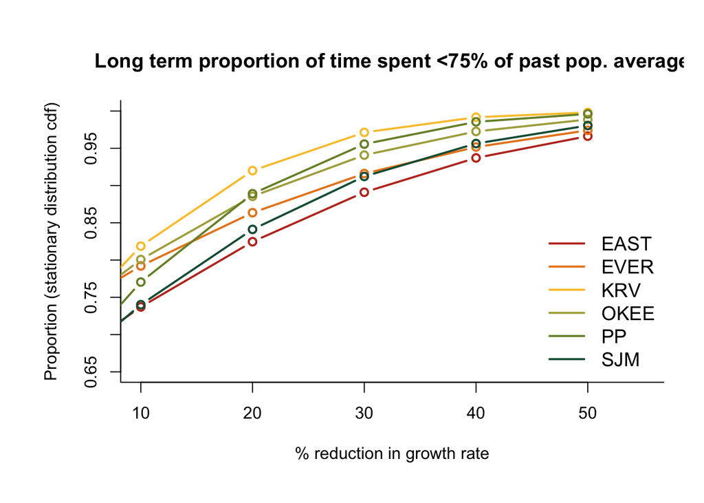

```r
pct.red2 <- (1-pct.red)*100
par(mfrow=c(1,1),oma=c(2,2,1,1), mar=c(4,4,4,1))
plot(25,0.8,type="n",xlab="% reduction in growth rate",main="Long term proportion of time spent <75% of past pop. average", ylim=c(0.65,1), xlim=c(10,55), bty="l", ylab="Proportion (stationary distribution cdf)")
for(i in 1:p){
  points(pct.red2,perc.redmat[i,], lty=1, lwd=2,type="b", col=cool.palette[i], xlab="", ylab="", main="")
}

legend("bottomright",legend=row.names(S4mat),lty=rep(1,6),lwd=rep(2,6),cex=1.15, col=cool.palette, bty="n")
```

```r
#![Long term proportion of time spent under 75% of past population averages for each deme](TimeSpentUnder75pct-pdetect.JPEG)<br>
```

And we can do the same but computing the proportion of time spent under 50% of past population averages

```r
perc.redmat50 <- matrix(0, nrow=p,ncol=nchanges)
rownames(perc.redmat50) <- row.names(S4mat)
colnames(perc.redmat50) <- pct.red
for(i in 1:nchanges){
  perc.redmat50[,i] <- plnorm(q=E.Ns*0.5, meanlog=muvec4kalman2*pct.red[i], sdlog=sqrt(Vars.inf))
}

print(perc.redmat50)
```

```
##              1.5        1.4        1.3       1.2       1.1         1       0.9
## EAST 0.067792622 0.11629859 0.18540530 0.2755152 0.3830510 0.5005034 0.6179119
## EVER 0.136178044 0.20754705 0.29726916 0.4014561 0.5132069 0.6239235 0.7252444
## KRV  0.007921733 0.02758843 0.07744633 0.1768491 0.3327184 0.5249581 0.7114488
## OKEE 0.050889194 0.10073651 0.17919434 0.2879057 0.4205107 0.5629053 0.6975146
## PP   0.005740177 0.02033605 0.05867578 0.1389348 0.2728395 0.4509040 0.6396383
## SJM  0.033144373 0.06930519 0.13018749 0.2206426 0.3392377 0.4764506 0.6165440
##            0.8       0.7       0.6       0.5
## EAST 0.7253270 0.8152685 0.8841945 0.9325374
## EVER 0.8108908 0.8777626 0.9259907 0.9581184
## KRV  0.8537476 0.9391483 0.9794581 0.9944209
## OKEE 0.8095372 0.8916068 0.9445370 0.9745885
## PP   0.7990863 0.9064542 0.9640777 0.9887249
## SJM  0.7427662 0.8431233 0.9135363 0.9571325
```

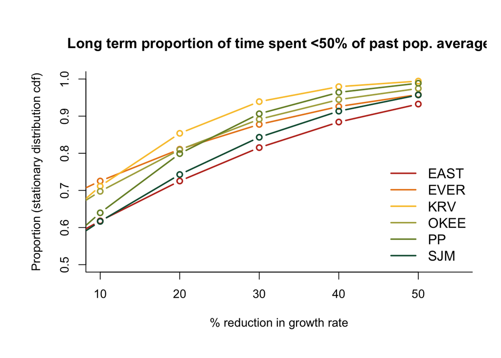

```r
pct.red2 <- (1-pct.red)*100
par(mfrow=c(1,1),oma=c(2,2,1,1), mar=c(4,4,4,1))
plot(25,0.6,type="n",xlab="% reduction in growth rate",main="Long term proportion of time spent <50% of past pop. average", ylim=c(0.5,1), xlim=c(10,55), bty="l", ylab="Proportion (stationary distribution cdf)")
for(i in 1:p){
  points(pct.red2,perc.redmat50[i,], lty=1, lwd=2,type="b", col=cool.palette[i], xlab="", ylab="", main="")
}

legend("bottomright",legend=row.names(S4mat),lty=rep(1,6),lwd=rep(2,6),cex=1.15, col=cool.palette, bty="n")
```

```r
#![Long term proportion of time spent under 50% of past population averages for each deme](TimeSpentUnder50pct-pdetect.JPEG)<br>
```

Taking the same approach we can ask what are the chances of the extreme event of the population size being under say one fourth of the past population mean for every deme:

```r
perc.redmat25 <- matrix(0, nrow=p,ncol=nchanges)
rownames(perc.redmat25) <- row.names(S4mat)
colnames(perc.redmat25) <- pct.red
for(i in 1:nchanges){
  perc.redmat25[,i] <- plnorm(q=E.Ns*0.25, meanlog=muvec4kalman2*pct.red[i], sdlog=sqrt(Vars.inf))
}

print(perc.redmat25)
```

```
##               1.5         1.4        1.3        1.2       1.1         1
## EAST 0.0195000200 0.038744321 0.07122777 0.12140972 0.1923609 0.2841727
## EVER 0.0713525092 0.118384592 0.18395108 0.26838031 0.3688020 0.4791301
## KRV  0.0012829148 0.005860287 0.02141178 0.06295811 0.1502445 0.2944727
## OKEE 0.0140847652 0.033179498 0.06982916 0.13175398 0.2238629 0.3444731
## PP   0.0007303887 0.003451427 0.01318819 0.04095101 0.1040359 0.2182800
## SJM  0.0075461919 0.019008372 0.04278955 0.08632891 0.1566713 0.2569580
##            0.9       0.8       0.7       0.6       0.5
## EAST 0.3929069 0.5107656 0.6276849 0.7338396 0.8220502
## EVER 0.5910916 0.6960400 0.7869072 0.8595783 0.9132618
## KRV  0.4819165 0.6735281 0.8275932 0.9250264 0.9734888
## OKEE 0.4835048 0.6245934 0.7506363 0.8497636 0.9183935
## PP   0.3831777 0.5728851 0.7468450 0.8739915 0.9480607
## SJM  0.3831294 0.5232087 0.6604490 0.7791036 0.8696313
```

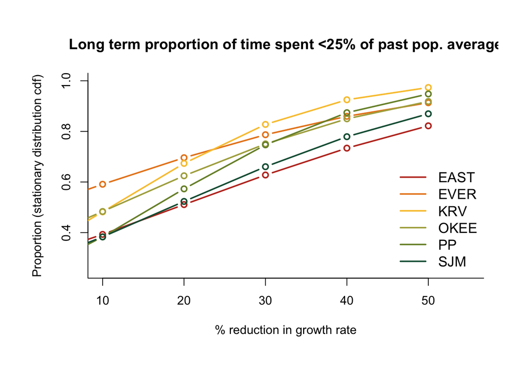

```r
par(oma=c(2,2,1,1), mar=c(4,4,4,1))
plot(25,0.20,type="n",xlab="% reduction in growth rate",main="Long term proportion of time spent <25% of past pop. average", ylim=c(0.25,1), xlim=c(10,55), bty="l", ylab="Proportion (stationary distribution cdf)")
for(i in 1:p){
  points(pct.red2,perc.redmat25[i,], lty=1, lwd=2,type="b", col=cool.palette[i], xlab="", ylab="", main="")
}

legend("bottomright",legend=row.names(S4mat),lty=rep(1,6),lwd=rep(2,6),cex=1.15, col=cool.palette, bty="n")
```

```r
#![Long term proportion of time spent under 25% of past population averages for each deme](TimeSpendUnder25-pdetect.JPEG)<br>
```

And we save our work